# homework2-506

Author

Zhixuan Li

Link to the repository: https://github.com/lizhixuan202603-sudo/homework2-506

```r
library(microbenchmark)
library(dplyr)
library(tidyr)
library(purrr)
library(broom)
library(ggplot2)
library(e1071)

set.seed(506)
```

# Problem 1: Random Walk with Momentum

## 1a. Simulation function

### i. Function `momentum_walk(n, p)`

```r
#' Random Walk with Momentum in 2D
#'
#' Simulates a particle moving on a 2D grid. The first step is chosen
#' uniformly from four directions; each subsequent step preserves the
#' previous direction with probability `p`, and otherwise chooses a new
#' direction uniformly from the four directions.
#'
#' @param n Positive integer. Number of steps (n >= 1).
#' @param p Numeric. Probability of preserving the previous direction
#'   (0 <= p <= 1).
#' @return A numeric vector of length 2, c(x, y), the final coordinates.
#' @examples
#' momentum_walk(10, 0.6)
momentum_walk <- function(n, p) {
  if (!is.numeric(n) || length(n) != 1 || is.na(n)) stop("n must be a single numeric value")
  if (!is.numeric(p) || length(p) != 1 || is.na(p)) stop("p must be a single numeric value")
  if (n < 1 || n != as.integer(n)) stop("n must be an integer >= 1")
  if (p < 0 || p > 1) stop("p must be in [0, 1]")

  dirs <- matrix(c(1, 0,
                  -1, 0,
                   0, 1,
                   0,-1), ncol = 2, byrow = TRUE)

  d <- sample(1:4, 1)
  x <- dirs[d, 1]; y <- dirs[d, 2]
  prev <- d

  if (n > 1) {
    for (i in 2:n) {
      if (runif(1) < p) {
        d <- prev
      } else {
        d <- sample(1:4, 1)
      }
      x <- x + dirs[d, 1]
      y <- y + dirs[d, 2]
      prev <- d
    }
  }
  c(x, y)
}

momentum_walk(10, 0.6)
```

```
[1] -2  0
```

### ii. Input sanitization

The function validates `n >= 1` (and integer) and `0 <= p <= 1`, raising an informative error otherwise.

```r
tryCatch(momentum_walk(0, 0.5),    error = function(e) message(e$message))
```

```
n must be an integer >= 1
```

```r
tryCatch(momentum_walk(10, 1.5),   error = function(e) message(e$message))
```

```
p must be in [0, 1]
```

```r
tryCatch(momentum_walk(10.5, 0.5), error = function(e) message(e$message))
```

```
n must be an integer >= 1
```

## 1b. Two implementations

### Version 1: `for` loop

```r
#' Random Walk with Momentum — for-loop implementation
#'
#' @param n Number of steps.
#' @param p Probability of preserving direction.
#' @return Final coordinates c(x, y).
momentum_walk1 <- function(n, p) {
  if (!is.numeric(n) || length(n) != 1 || is.na(n)) stop("n must be a single numeric value")
  if (!is.numeric(p) || length(p) != 1 || is.na(p)) stop("p must be a single numeric value")
  if (n < 1 || n != as.integer(n)) stop("n must be an integer >= 1")
  if (p < 0 || p > 1) stop("p must be in [0, 1]")

  dirs <- matrix(c(1, 0, -1, 0, 0, 1, 0, -1), ncol = 2, byrow = TRUE)

  d    <- sample(1:4, 1)
  step <- dirs[d, ]
  x <- step[1]; y <- step[2]

  for (i in 2:n) {
    if (runif(1) < p) {
      d <- d
    } else {
      d <- sample(1:4, 1)
    }
    step <- dirs[d, ]
    x <- x + step[1]
    y <- y + step[2]
  }
  c(x, y)
}
```

**Logic.** The `for` loop advances the particle step-by-step. At each step it first decides whether to keep the previous direction, then updates the coordinates. The approach is intuitive, though loops in R are relatively slow.

### Version 2: `sapply` implementation

```r
#' Random Walk with Momentum — sapply implementation
#'
#' @param n Number of steps.
#' @param p Probability of preserving direction.
#' @return Final coordinates c(x, y).
momentum_walk2 <- function(n, p) {
  if (!is.numeric(n) || length(n) != 1 || is.na(n)) stop("n must be a single numeric value")
  if (!is.numeric(p) || length(p) != 1 || is.na(p)) stop("p must be a single numeric value")
  if (n < 1 || n != as.integer(n)) stop("n must be an integer >= 1")
  if (p < 0 || p > 1) stop("p must be in [0, 1]")

  dirs <- matrix(c(1, 0, -1, 0, 0, 1, 0, -1), ncol = 2, byrow = TRUE)

  keep <- c(TRUE, runif(n - 1) < p)
  rand <- sample(1:4, n, replace = TRUE)

  idx <- integer(n)
  idx[1] <- rand[1]
  sapply(2:n, function(i) {
    if (keep[i]) {
      idx[i] <<- idx[i - 1]
    } else {
      idx[i] <<- rand[i]
    }
    idx[i]
  })

  xy <- dirs[idx, , drop = FALSE]
  c(sum(xy[, 1]), sum(xy[, 2]))
}
```

**Logic.** All “keep” decisions and candidate directions are generated vectorially first; then `sapply` sequentially resolves each step’s direction; finally coordinates are summed in one shot, avoiding an explicit `for` loop.

### Demonstration

```r
set.seed(1)
momentum_walk1(10, 0.6)
```

```
[1] -1  1
```

```r
momentum_walk2(10, 0.6)
```

```
[1] 2 0
```

```r
momentum_walk1(1000, 0.6)
```

```
[1] -39 -51
```

```r
momentum_walk2(1000, 0.6)
```

```
[1]  27 -15
```

## 1c. Reproducibility

```r
set.seed(506)
r1 <- momentum_walk1(10, 0.6)
r2 <- momentum_walk1(10, 0.6)
set.seed(506)
r3 <- momentum_walk1(10, 0.6)

identical(r1, r3)
```

```
[1] TRUE
```

```r
set.seed(506)
m1 <- momentum_walk1(1000, 0.6)
set.seed(506)
m2 <- momentum_walk1(1000, 0.6)
identical(m1, m2)
```

```
[1] TRUE
```

**Explanation.** `set.seed()` sets the internal state of the pseudo-random number generator. With the same seed, all subsequent random calls produce an identical sequence, so results are reproducible.

## 1d. Does momentum matter?

### i. One simulation for each p

```r
set.seed(506)
p_vals <- c(0, 0.5, 0.9)
res_d  <- sapply(p_vals, function(pp) {
  pos <- momentum_walk1(1000, pp)
  sqrt(sum(pos^2))
})
names(res_d) <- paste0("p=", p_vals)
res_d
```

```
      p=0     p=0.5     p=0.9
 23.19483  62.28965 157.00318
```

### ii. Larger momentum leads to larger final distance

The output above shows that D increases clearly as p increases.

### iii. Reasoning

When p = 0, each step is independent, so the particle performs a classical 2D random walk; the variance of displacement grows linearly with steps, and the final distance is roughly sqrt(n). When p approaches 1, the particle keeps moving in nearly the same direction, so displacement grows nearly linearly (~n), and the final distance is much larger than a random walk. Higher momentum means more “straight-line-like” motion, so cancellations are less likely.

## 1e. Monte Carlo simulation

```r
p_grid <- c(0, 0.25, 0.5, 0.75, 0.9)
n_walk <- 1000
n_step <- 1000

set.seed(506)
mean_distance <- sapply(p_grid, function(pp) {
  dists <- replicate(n_walk, {
    pos <- momentum_walk1(n_step, pp)
    sqrt(sum(pos^2))
  })
  mean(dists)
})

data.frame(p = p_grid, mean_distance = mean_distance)
```

```
     p mean_distance
1 0.00      27.75439
2 0.25      36.24280
3 0.50      48.41756
4 0.75      75.69467
5 0.90     122.89538
```

### iv. Conclusion

As p increases, the mean final distance increases monotonically. The reason is the same as in 1d: larger p means more persistent direction, so the trajectory behaves more like a straight line and is less likely to be cancelled out by random reversals.

## 1f. Compare computational performance

```r
set.seed(506)
bench_small <- microbenchmark(
  loop  = momentum_walk1(1000, 0.6),
  apply = momentum_walk2(1000, 0.6),
  times = 50
)
set.seed(506)
bench_large <- microbenchmark(
  loop  = momentum_walk1(100000, 0.6),
  apply = momentum_walk2(100000, 0.6),
  times = 5
)

print(bench_small)
```

```
Unit: microseconds
  expr      min       lq      mean   median       uq      max neval cld
  loop 1083.999 1178.996 1268.9598 1213.169 1274.895 2394.482    50  a
 apply  366.581  379.127  390.1609  385.236  400.529  440.381    50   b
```

```r
print(bench_large)
```

```
Unit: milliseconds
  expr       min        lq     mean    median        uq       max neval cld
  loop 120.66275 121.21994 133.9717 128.53402 129.09092 170.35090     5  a
 apply  40.02145  43.47156  43.9312  43.53216  45.17774  47.45307     5   b
```

# Problem 2: Monte Carlo Simulation of Campus Bus Arrivals

```r
#' Simulate the total number of passengers boarding the bus in one day
#'
#' @return A single numeric value: the total number of passengers
#'   across all hours of one simulated day.
simulate_one_day <- function() {
  morning <- sum(rpois(3, 4))
  nine_am <- rnorm(1, mean = 45, sd = sqrt(16))
  midday  <- sum(rpois(6, 15))
  four_pm <- rnorm(1, mean = 55, sd = sqrt(25))
  evening <- sum(rpois(6, 9))
  morning + nine_am + midday + four_pm + evening
}

set.seed(506)
n_days <- 10000
daily  <- replicate(n_days, simulate_one_day())

mean(daily)
```

```
[1] 256.0418
```

**Interpretation.** From the expectations of each block:

- 6-8 AM: 3 x 4 = 12
- 9 AM: 45
- 10 AM-3 PM: 6 x 15 = 90
- 4 PM: 55
- 5-10 PM: 6 x 9 = 54

Theoretical total expectation = 12 + 45 + 90 + 55 + 54 = **256**.

**Conclusion.** The estimated average total number of passengers per day is approximately **256**, matching the theoretical expectation.

# Problem 3: Linear Regression

## 3a. Data preparation and de-identification

```r
youtube <- read.csv(
  "https://raw.githubusercontent.com/rfordatascience/tidytuesday/master/data/2021/2021-03-02/youtube.csv"
)
```

We remove variables that uniquely identify each commercial (`brand`, `title`, URLs, `channel_title`, publication info, etc.):

```r
youtube_clean <- youtube %>%
  select(-brand, -title,
         -superbowl_ads_dot_com_url, -youtube_url, -thumbnail,
         -channel_title,
         -published_at, -description,
         -id, -etag, -kind)

dim(youtube_clean)
```

```
[1] 247  14
```

**Result.** The cleaned dataset has **247 rows** and **14 columns**.

## 3b. Exploring potential outcomes

The five engagement variables are:

- `view_count`
- `like_count`
- `dislike_count`
- `favorite_count`
- `comment_count`

```r
engagement_vars <- c("view_count", "like_count", "dislike_count",
                     "favorite_count", "comment_count")

dist_long <- data.frame(
  variable = engagement_vars,
  mean     = sapply(engagement_vars, function(v) mean(youtube_clean[[v]],   na.rm = TRUE)),
  median   = sapply(engagement_vars, function(v) median(youtube_clean[[v]], na.rm = TRUE)),
  max      = sapply(engagement_vars, function(v) max(youtube_clean[[v]],    na.rm = TRUE)),
  skewness = sapply(engagement_vars, function(v) e1071::skewness(youtube_clean[[v]], na.rm = TRUE)),
  zero_pct = sapply(engagement_vars, function(v) mean(youtube_clean[[v]] == 0, na.rm = TRUE) * 100)
)
dist_long
```

```
                     variable         mean median       max  skewness  zero_pct
view_count         view_count 1407556.4589  41379 176373378 13.634058   0.00000
like_count         like_count    4146.0311    130    275362  8.659207   4.00000
dislike_count   dislike_count     833.5378      7     92990 11.401227  20.88889
favorite_count favorite_count       0.0000      0         0       NaN 100.00000
comment_count   comment_count     188.6396     10      9190  7.884004  18.46847
```

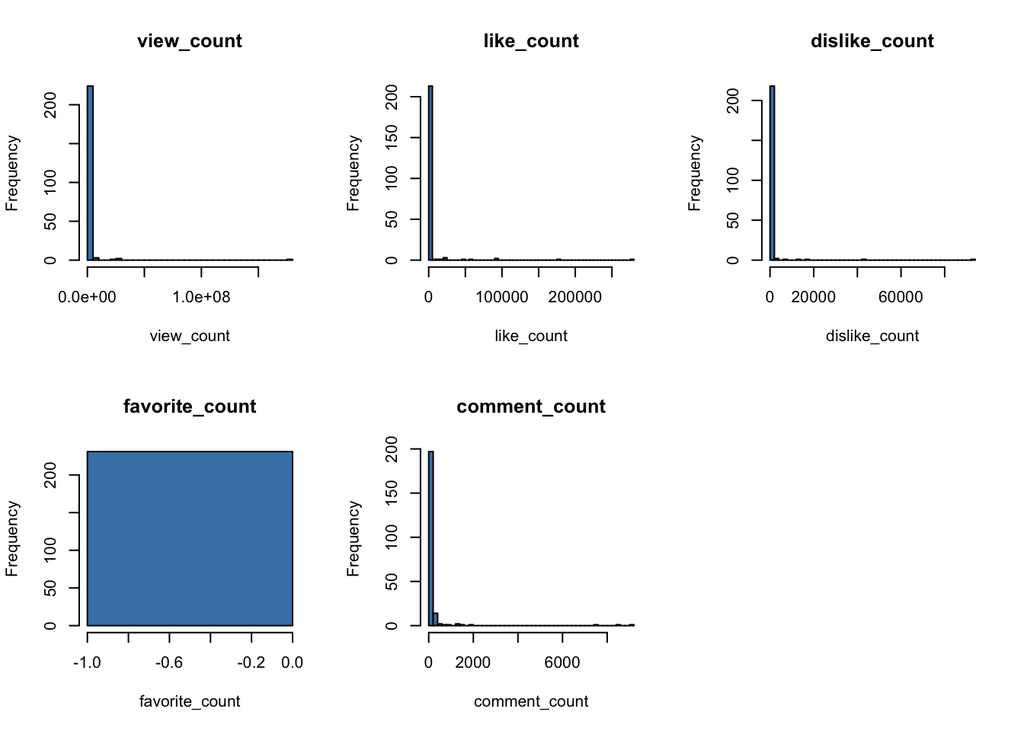

```r
par(mfrow = c(2, 3))
for (v in engagement_vars) {
  hist(youtube_clean[[v]], main = v, xlab = v, breaks = 40, col = "steelblue")
}
par(mfrow = c(1, 1))
```

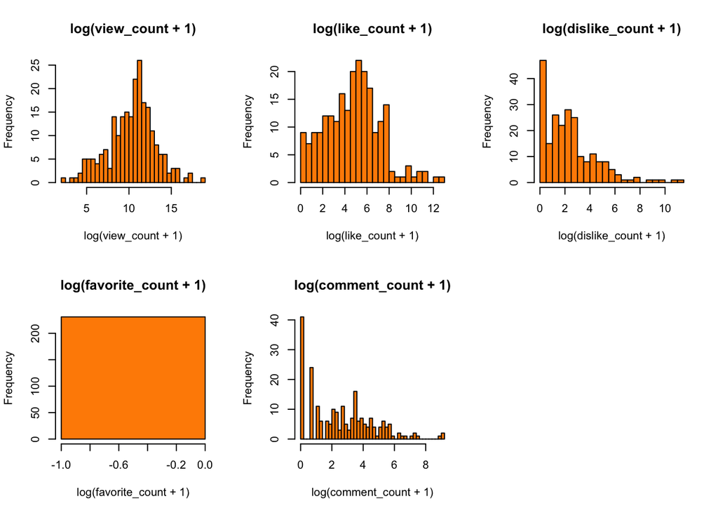

```r
par(mfrow = c(2, 3))
for (v in engagement_vars) {
  hist(log(youtube_clean[[v]] + 1), main = paste0("log(", v, " + 1)"),
       xlab = paste0("log(", v, " + 1)"), breaks = 40, col = "darkorange")
}
par(mfrow = c(1, 1))
```

### Apply all data prep: binary coercion + log transform

This is the single chunk that prepares everything for 3c and 3d.

```r
binary_vars <- c("funny", "show_product_quickly", "patriotic",
                 "celebrity", "danger", "animals", "use_sex")

youtube_clean <- youtube_clean %>%
  mutate(across(all_of(binary_vars), function(x) as.numeric(as.logical(x)))) %>%
  mutate(
    log_view    = log(view_count + 1),
    log_like    = log(like_count + 1),
    log_dislike = log(dislike_count + 1),
    log_comment = log(comment_count + 1)
  )

str(youtube_clean[c(binary_vars,
                    "log_view", "log_like", "log_dislike", "log_comment")])
```

```
'data.frame':   247 obs. of  11 variables:
 $ funny               : num  0 1 1 0 1 1 1 0 1 0 ...
 $ show_product_quickly: num  0 1 0 1 1 1 0 0 1 1 ...
 $ patriotic           : num  0 0 0 0 0 0 0 0 0 1 ...
 $ celebrity           : num  0 1 0 0 0 1 1 1 1 1 ...
 $ danger              : num  0 1 1 0 1 1 0 0 0 1 ...
 $ animals             : num  0 0 1 0 1 1 1 0 1 0 ...
 $ use_sex             : num  0 0 0 0 1 0 0 0 0 0 ...
 $ log_view            : num  12.07 10.77 11.87 5.29 9.53 ...
 $ log_like            : num  7.12 6.19 4.87 1.1 3.04 ...
 $ log_dislike         : num  3.66 2.71 2.77 0 1.39 ...
 $ log_comment         : num  NA 2.71 2.3 0 1.1 ...
```

```r
sapply(c("log_view", "log_like", "log_dislike", "log_comment"),
       function(v) e1071::skewness(youtube_clean[[v]], na.rm = TRUE))
```

```
   log_view    log_like log_dislike log_comment
 -0.1923383   0.2847672   1.3319769   0.6060042
```

```r
stopifnot(all(c("log_view", "log_like", "log_dislike", "log_comment")
              %in% names(youtube_clean)))
stopifnot(all(binary_vars %in% names(youtube_clean)))
```

**Interpretation.** `log_view`, `log_like`, and `log_comment` are now approximately symmetric (|skewness| < 0.7). `log_dislike` retains mild right-skew (skewness = 1.33) but is dramatically improved over the raw scale. All seven binary predictors are now numeric 0/1.

## 3c. Fitting linear regression models

### Setup: outcomes, helper function

```r
outcomes <- c("log_view", "log_like", "log_dislike", "log_comment")

#' Fit a linear regression of an outcome on one binary predictor,
#' adjusting for year as a continuous covariate.
#'
#' @param outcome   Character. Name of the (log-transformed) outcome.
#' @param predictor Character. Name of the binary (0/1) predictor.
#' @param data      Data frame. Defaults to `youtube_clean`.
#' @return A one-row tibble with columns `coef`, `p_value`, `n_used`.
#' @examples
#' fit_summary("log_view", "funny")
fit_summary <- function(outcome, predictor, data = youtube_clean) {
  m  <- lm(as.formula(paste(outcome, "~", predictor, "+ year")), data = data)
  td <- broom::tidy(m) %>% filter(term == predictor)

  if (nrow(td) == 0)
    return(tibble(coef = NA_real_, p_value = NA_real_, n_used = nobs(m)))

  tibble(coef    = td$estimate,
         p_value = td$p.value,
         n_used  = nobs(m))
}
```

### Fit all 28 models

```r
results <- crossing(outcome = outcomes, predictor = binary_vars) %>%
  mutate(fit = map2(outcome, predictor, fit_summary)) %>%
  unnest(fit)

results
```

```
# A tibble: 28 × 5
   outcome     predictor               coef p_value n_used
   <chr>       <chr>                  <dbl>   <dbl>  <int>
 1 log_comment animals              -0.192    0.499    222
 2 log_comment celebrity             0.228    0.456    222
 3 log_comment danger                0.106    0.721    222
 4 log_comment funny                 0.0475   0.879    222
 5 log_comment patriotic             0.515    0.169    222
 6 log_comment show_product_quickly  0.346    0.247    222
 7 log_comment use_sex              -0.349    0.274    222
 8 log_dislike animals              -0.0738   0.797    225
 9 log_dislike celebrity            -0.283    0.362    225
10 log_dislike danger                0.185    0.538    225
# ℹ 18 more rows
```

### Sample size per outcome

```r
results %>% distinct(outcome, n_used) %>% arrange(outcome)
```

```
# A tibble: 4 × 2
  outcome     n_used
  <chr>        <int>
1 log_comment    222
2 log_dislike    225
3 log_like       225
4 log_view       231
```

### 3c-1. Significant characteristics at alpha = 0.05

```r
sig <- results %>%
  filter(!is.na(p_value), p_value < 0.05) %>%
  arrange(outcome, p_value)
sig
```

```
# A tibble: 0 × 5
# ℹ 5 variables: outcome <chr>, predictor <chr>, coef <dbl>, p_value <dbl>,
#   n_used <int>
```

**Written answer.** Of the 247 ads in the cleaned dataset, **231** are used in every `log_view` model (16 rows have missing values in `log_view` or `year`); the other outcomes use **225** (`log_like`, `log_dislike`) and **222** (`log_comment`) observations. After adjusting for `year`, **none** of the seven binary commercial characteristics is statistically significant at alpha = 0.05 for any of the four engagement outcomes. The smallest p-value across all 28 models is **0.0941** (for `log_view ~ danger`), which is marginally non-significant.

**Sensitivity check.** To verify that `year` is not masking the effect of `funny`, we compare `lm(log_view ~ funny + year)` with `lm(log_view ~ funny)`:

```r
m_with    <- lm(log_view ~ funny + year, data = youtube_clean)
m_without <- lm(log_view ~ funny,        data = youtube_clean)

c(with_year    = summary(m_with)$coefficients["funny", "Pr(>|t|)"],
  without_year = summary(m_without)$coefficients["funny", "Pr(>|t|)"])
```

```
   with_year without_year
   0.2051061    0.2988373
```

The p-value for `funny` is **0.205** with year and **0.299** without year. Removing `year` does not reveal a hidden association. This confirms that the non-significance reflects genuine weak signal in the data rather than a modeling artifact.

### 3c-2. Direction of significant associations

```r
sig <- sig %>% mutate(direction = ifelse(coef > 0, "positive", "negative"))
sig
```

```
# A tibble: 0 × 6
# ℹ 6 variables: outcome <chr>, predictor <chr>, coef <dbl>, p_value <dbl>,
#   n_used <int>, direction <lgl>
```

**Written answer.** **Not applicable.** No association reached alpha = 0.05 in any of the 28 models, so there is no significant positive or negative association to report. A few coefficients fall in the “marginally significant” range (0.05 < p < 0.10) — for example, `danger` on `log_view` with beta-hat = **0.667** and p = **0.0941** — suggesting weak positive associations that a larger sample might confirm, but none crosses the stated significance threshold.

### 3c-3. Largest positive association with view counts

```r
top_view <- results %>%
  filter(outcome == "log_view", !is.na(coef), coef > 0) %>%
  arrange(desc(coef)) %>%
  slice(1)
top_view
```

```
# A tibble: 1 × 5
  outcome  predictor  coef p_value n_used
  <chr>    <chr>     <dbl>   <dbl>  <int>
1 log_view danger    0.667  0.0941    231
```

**Written answer.** Among all predictors with a positive estimated coefficient on `log_view`, the largest is **`danger`** with beta-hat = **0.667** (p = **0.0941**, n = 231). However, this association is **not statistically significant** at alpha = 0.05. Because the outcome is on the `log(x + 1)` scale, the point estimate corresponds to an approximate `exp(0.667) - 1 = 94.8%` increase in view counts for ads that feature danger, holding year fixed. But this estimate is not distinguishable from zero at the standard significance level.

## 3d. Estimating regression coefficients using matrix algebra

### Select the predictor with the smallest p-value for `log_view`

```r
best_view <- results %>%
  filter(outcome == "log_view", !is.na(p_value)) %>%
  arrange(p_value) %>%
  slice(1)
best_view
```

```
# A tibble: 1 × 5
  outcome  predictor  coef p_value n_used
  <chr>    <chr>     <dbl>   <dbl>  <int>
1 log_view danger    0.667  0.0941    231
```

The predictor with the smallest p-value is **`danger`** (beta-hat = 0.667, p = 0.0941).

### Build y and X, drop NAs consistently

```r
dat_3d <- data.frame(
  y      = youtube_clean$log_view,
  danger = youtube_clean$danger,
  year   = youtube_clean$year
)
dat_3d <- na.omit(dat_3d)

n_3d <- nrow(dat_3d)
cat("Effective sample size:", n_3d, "\n")
```

```
Effective sample size: 231
```

```r
y_3d <- dat_3d$y
X_3d <- cbind(1, dat_3d$danger, dat_3d$year)
```

### Compute beta-hat via the matrix formula

```r
XtX_inv  <- solve(t(X_3d) %*% X_3d)
Xty      <- t(X_3d) %*% y_3d
beta_hat <- as.vector(XtX_inv %*% Xty)
names(beta_hat) <- c("(Intercept)", "danger", "year")
beta_hat
```

```
 (Intercept)       danger         year
-31.39149243   0.66678076   0.02065641
```

### Fit the same model with `lm()` and compare

```r
m_lm    <- lm(log_view ~ danger + year, data = youtube_clean)
beta_lm <- coef(m_lm)

comparison <- data.frame(
  term       = names(beta_lm),
  matrix_est = beta_hat,
  lm_est     = as.vector(beta_lm),
  abs_diff   = abs(beta_hat - as.vector(beta_lm))
)
comparison
```

```
                   term   matrix_est       lm_est     abs_diff
(Intercept) (Intercept) -31.39149243 -31.39149243 3.833769e-10
danger           danger   0.66678076   0.66678076 2.856604e-13
year               year   0.02065641   0.02065641 1.493423e-13
```

### Compare standard errors

```r
resid      <- y_3d - X_3d %*% beta_hat
RSS        <- sum(resid^2)
sigma2_hat <- RSS / (n_3d - ncol(X_3d))
SE_beta    <- sqrt(diag(sigma2_hat * XtX_inv))

comparison_se <- data.frame(
  term      = names(beta_lm),
  matrix_SE = as.vector(SE_beta),
  lm_SE     = summary(m_lm)$coefficients[, "Std. Error"]
)
comparison_se
```

```
                   term   matrix_SE       lm_SE
(Intercept) (Intercept) 63.93249584 63.93249584
danger           danger  0.39657536  0.39657536
year               year  0.03179813  0.03179813
```

### Written answer

From the 28 models in 3c, the binary characteristic with the smallest p-value for `log_view` is **`danger`** (beta-hat = 0.667, p = 0.0941). We fit the model

log_view = beta_0 + beta_1 * danger + beta_2 * year + epsilon

using two approaches. First, we constructed the design matrix X = [1, danger, year] with an intercept column, removed rows with missing values consistently from y and X (leaving n = 231), and computed the closed-form least-squares estimate beta-hat = (X’X)^(-1) X’y via solve() and %*%. Second, we fit the same model with lm().

Estimated coefficients:

| Term | Matrix estimate | lm() estimate | Absolute difference |
| --- | --- | --- | --- |
| (Intercept) | -31.39149243 | -31.39149243 | 3.83e-10 |
| danger | 0.66678076 | 0.66678076 | 2.86e-13 |
| year | 0.02065641 | 0.02065641 | 1.49e-13 |

Standard errors computed from sigma^2 * (X’X)^(-1) also match lm()’s standard errors to machine precision:

| Term | Matrix SE | lm() SE |
| --- | --- | --- |
| (Intercept) | 63.93249584 | 63.93249584 |
| danger | 0.39657536 | 0.39657536 |
| year | 0.03179813 | 0.03179813 |

The two sets of estimates and standard errors agree to machine precision, confirming that R’s lm() uses exactly the closed-form least-squares solution beta-hat = (X’X)^(-1) X’y.